# Dear_Colleagues_project1

2026-02-11

### Authors’ Contributions

Group 242

**Julia Kovalchuk**: Participated in topic discussion, coded the bar plots’ parts and interpreted them.

**Julia Berdnikova**: Participated in topic discussion, coded the box plot part and interpreted it

**Darya Kistanova**: Participated in topic discussion, conducted HTML-formatting.

**Anastasiia Kurlovich**: Participated in topic discussion, coded the scatter plot part and interpreted it

**Polina Aleksandrova**: Participated in topic discussion, coded the variable description & data filtering part, interpreted the stacked bar plot.

### Problem Outline

For the first project we have chosen Italy from the European Social Survey dataset. Our scientific interest focuses on the relationship between Italians’ working life and their health. The **research question** can be formulated as **how labor conditions affect workers’ health in Italy**?

### Data Filtering

Here we filtered our dataset, limiting it to only Italy-related records and variables of our interest. We also **removed** all specially encoded values which refer to different kinds of NAs (due to refusal, lack of answer and others, coded as ‘66’, ‘777’, ‘8888’ and so on). Also we **renamed** the variables with more intuitive names using rename() from dplyr for quicker navigation between them. The **variables chosen include** Internet usage, age, type of organization a person works at, subjective perception of the degree of control at work, subjective health evaluation, smoking habit, drinking habit, dietary habit (vegetables consumption) and working hours per week.

```r
ess$cntry <- as.factor(ess$cntry)

ess <- ess %>%
  filter(cntry == 'IT')

ess_italy <- ess %>%
  select(netustm, agea, alcwknd, wkdcorga, tporgwk, health, cgtsmok, alcfreq, dosprt, eatveg, wkhtot) %>%
  filter(!netustm %in% c(6666, 7777, 8888, 9999, 1440),
         !alcwknd %in% c(6666, 7777),
         !agea %in% c(999),
         !wkdcorga %in% c(66, 77, 88, 99),
         !alcwknd %in% c(2208),
         !health %in% c(7, 8, 9),
         !tporgwk %in% c(66, 77, 88, 99),
         !alcfreq %in% c(77, 88, 99),
         !cgtsmok %in% c(7, 8, 9),
         !dosprt %in% c(77, 88),
         !eatveg %in% c(77, 88, 99),
         !wkhtot %in% c(666, 777, 888, 999)) %>%
  rename(net_usage_mins = netustm,
         age = agea,
         alcohol_weekends_grams = alcwknd,
         work_org = wkdcorga,
         type_of_org = tporgwk,
         smoking = cgtsmok,
         drinking = alcfreq,
         sport_activity = dosprt,
         veggies = eatveg,
         total_work_per_week = wkhtot)
```

### Variable Types and Descriptive Statistics

Our first step was to describe the data we have through types of variables, measures of central tendency and variables’ distribution (the following 2 chunks of code). For ratio variables we used **histograms** and for factors (nominal and ordinal variables) we used **bar plots**. We combined the plots by using ggplot’s facet_wrap layer, so that each distribution is visible next to each other.

```r
vars <- c("drinking", "smoking", "type_of_org", "health", "veggies")
ess_italy[vars] <- lapply(ess_italy[vars], as.factor)

describe(ess_italy) %>%
  select(n, mean, sd, median, min, max, range)
```

```
##                          n   mean     sd median min max range
## net_usage_mins         947 188.20 139.16    150  10 900   890
## age                    947  47.70  14.11     48  18  86    68
## alcohol_weekends_grams 947  42.59  42.82     26   0 426   426
## work_org               947   5.54   3.41      6   0  10    10
## type_of_org*           947   3.76   1.03      4   1   6     5
## health*                947   1.92   0.71      2   1   5     4
## smoking*               947   3.92   1.92      4   1   6     5
## drinking*              947   3.00   1.57      3   1   6     5
## sport_activity         947   2.39   1.90      2   0   7     7
## veggies*               947   2.92   1.08      3   1   7     6
## total_work_per_week    947  39.63  13.84     40   0 168   168
```

**Findings**: From the table above we can see the measures of central tendency for numeric variable (without “*” symbol) and summarize that the median Internet usage per day among Italians is 150 mins (approx. 2,5 hours), the median age in the sample is 48, the median for alcohol consumption is 26 grams on Weekends, the median number of physically active days per week is 2 per one person and the median number of working hours a week is 40 (which corresponds to the world-wide labour standard).

For bar plots we transformed the data into a longer format so that it would fit facet_wrap layer nicely.

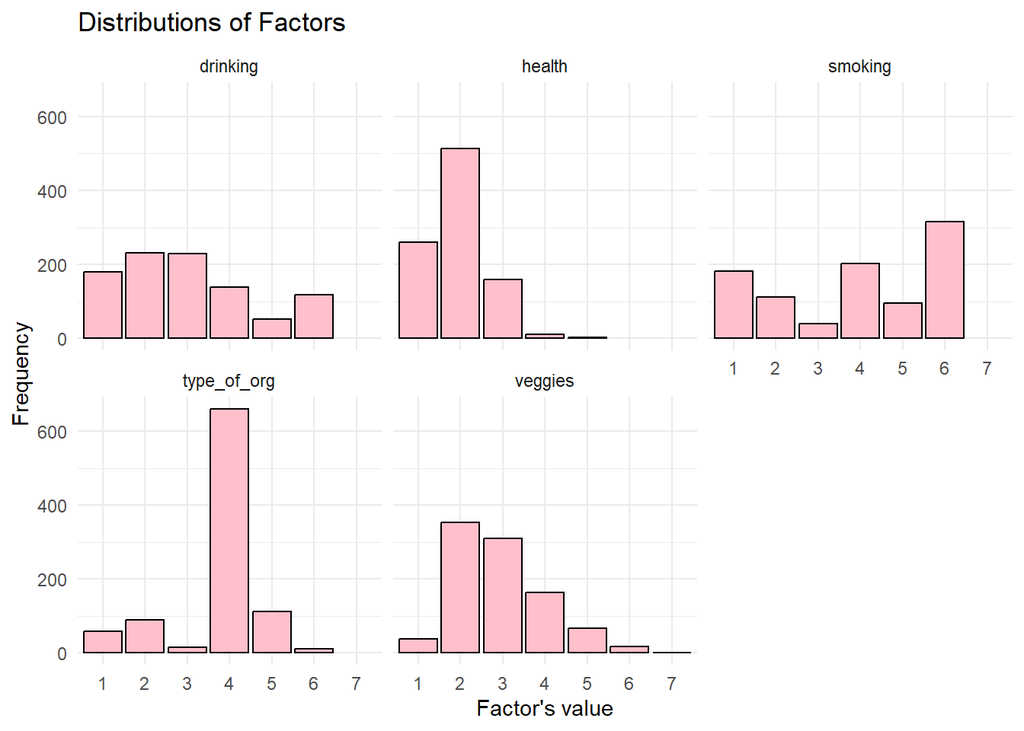

```r
ess_italy %>%
  select(drinking, smoking, health, veggies, type_of_org) %>%
  pivot_longer(everything()) %>%
  ggplot(aes(value))+
  geom_bar(fill = "pink", color = 'black')+
  facet_wrap(~name)+
  theme_minimal()+
  labs(title = 'Distributions of Factors',
       x = "Factor's value",
       y = 'Frequency')
```

**Findings**: The picture shows that the majority of observations in the sample: work for private companies, eat vegetables twice a day, have never smoked, drink alcohol several times a week or once a week and consider their health to be generally good.

For histograms we filtered 2 variables with their approximate “threshold” values which indicated where the absolute majority of observations fell, beyond which there were outliers. It made plots more informative.

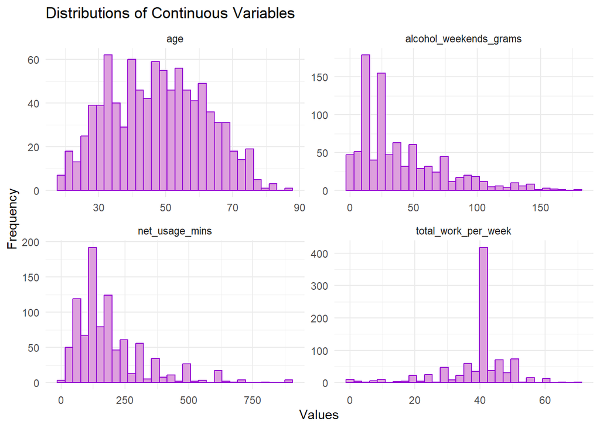

```r
ess_italy %>%
  select(net_usage_mins, age, alcohol_weekends_grams, total_work_per_week) %>%
  filter(alcohol_weekends_grams < 200,
        total_work_per_week < 75) %>%
  pivot_longer(everything()) %>%
  ggplot(aes(value))+
  geom_histogram(fill = "plum", color = 'darkviolet')+
  facet_wrap(~name, scales = "free")+
  theme_minimal()+
  labs(title = 'Distributions of Continuous Variables',
       x = "Values",
       y = 'Frequency')
```

### Interpretation: **Bar plot**

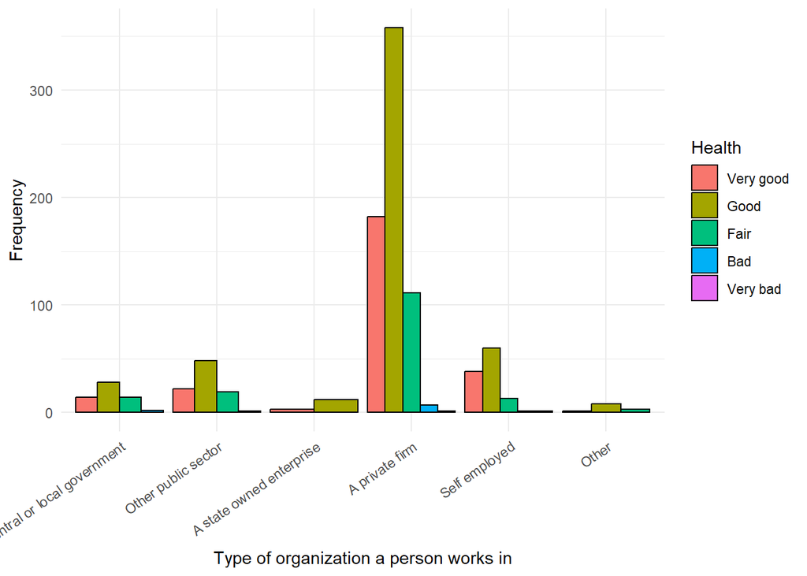

```r
ess_italy <- ess_italy %>%
  mutate(health_levels = factor(health,
                         levels = c('1', '2', '3', '4', '5'),
                         labels = c('Very good','Good','Fair', 'Bad','Very bad')),
    org_type = factor(type_of_org, levels = c(1, 2, 3, 4, 5, 6), labels = c("Central or local government", "Other public sector", "A state owned enterprise", "A private firm", "Self employed", "Other")))

ess_italy %>%
  ggplot(aes(x = org_type, fill = health_levels))+
  geom_bar(position = "dodge", color = "black")+
  labs(x = "Type of organization a person works in", y = "Frequency", fill = "Health")+
  theme_minimal()+
  theme(axis.text.x = element_text(angle = 35, hjust = 1))
```

In this bar plot we are comparing the health level of the workers in different types of organizations. The x axis represents the type of organization, y axis is the number of observations and the columns are filled with the health level of the workers. Private firms have the largest amount of observations. By looking at the graph, we can say that the most workers feel good (level 2), fever amount of workers feel very good (level 3) and less people answered that they feel ‘fair’ (level 3). The other health levels ‘bad’ and ‘very bad’ are the lest common report in every type of organizations. Self-reported health level is moderate in all organizations, but the sample is heavily concentrated in ‘private firm’ type of organizations.

### Interpretation: **Stacked bar plot**

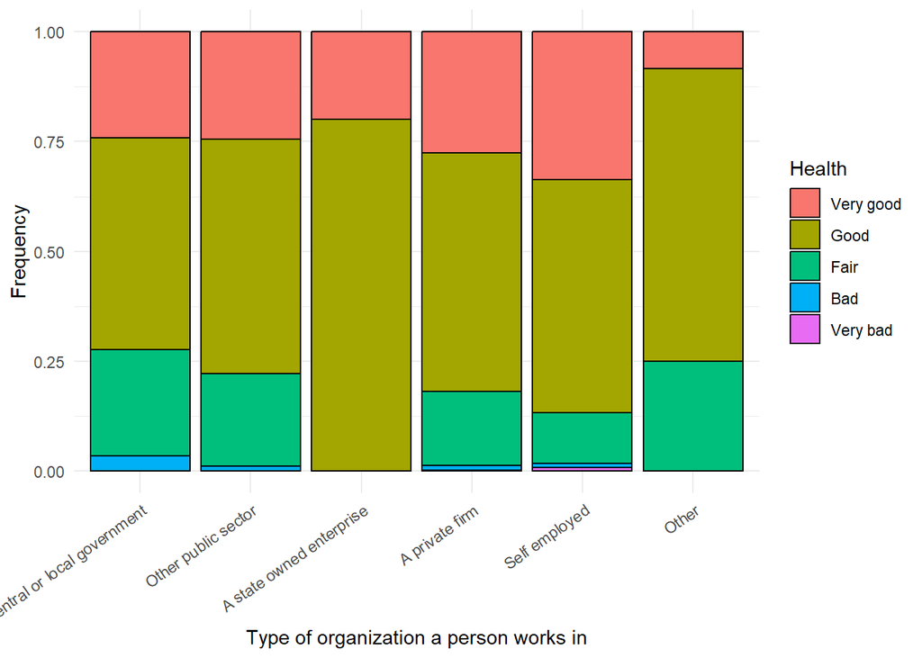

```r
ggplot(ess_italy, aes(x = org_type, fill = health_levels))+
  geom_bar(position = "fill", color = "black")+
  labs(x = "Type of organization a person works in", y = "Frequency", fill = "Health")+
  theme_minimal()+
  theme(axis.text.x = element_text(angle = 35, hjust = 1))
```

This version of the bar plot represents the relative numbers of subjective health evaluations across different types of organizations, depicted in the previous plot. This picture shows that the distribution of different “health points” varies across the working places: the most subjectively health individuals (“Very good”) are self-employed, yet the gross health is higher in state-owned enterprises. Individuals employed in central/local governments or non-conventional types of organizations (“Other”) report their health as”fair” of “bad” more often than in other types.

### Interpretation: **Scatter plot**

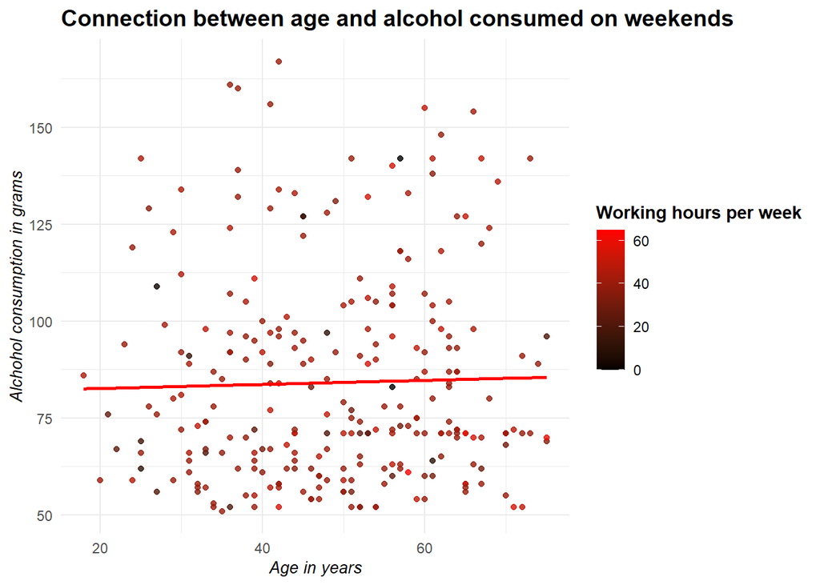

```r
ess_italy %>%
  filter(alcohol_weekends_grams>50, alcohol_weekends_grams<175,total_work_per_week<75)%>%
  ggplot(aes(age,alcohol_weekends_grams,color = total_work_per_week))+
  geom_point(alpha = 0.8, size = 1.5)+
  scale_color_gradient(low = "black", high = "red",
                       name = "Working hours per week")+
  labs(title = "Connection between age and alcohol consumed on weekends",
       x = "Age in years",
       y = "Alchohol consumption in grams")+
  geom_smooth(method = "lm", se = FALSE, color = "red")+
  theme_minimal()+
theme(plot.title = element_text(face = "bold", size = 14),
    axis.title = element_text(face = "italic", size = 10),
    legend.title = element_text(face = "bold"),
    legend.position = "right")
```

For the scatterplot we chose continous variables: amount of the consumed alcohol on the weekends, total working hours per week and age. Because the data is distributed not equally the graph would look stacked. That is why we filtered the borders (for the alco consumption - more then 50 and less than 175, for the working hours <75) to get nice visuals. Age wasn’t filtered. The dots are gradient-coloured for the working hours. Also we made an attempt to draw a trendline. As it can be seen from the scatterplot we got, the connection between the age and the amount of the consumed alcohol is weak and almost non-visible, so the trendline looks parallel to the x-axis. The connection between working hours and other two variables is weak as well, we don’t see the obvious gradient color_change.

### Interpretation: **Boxplot**

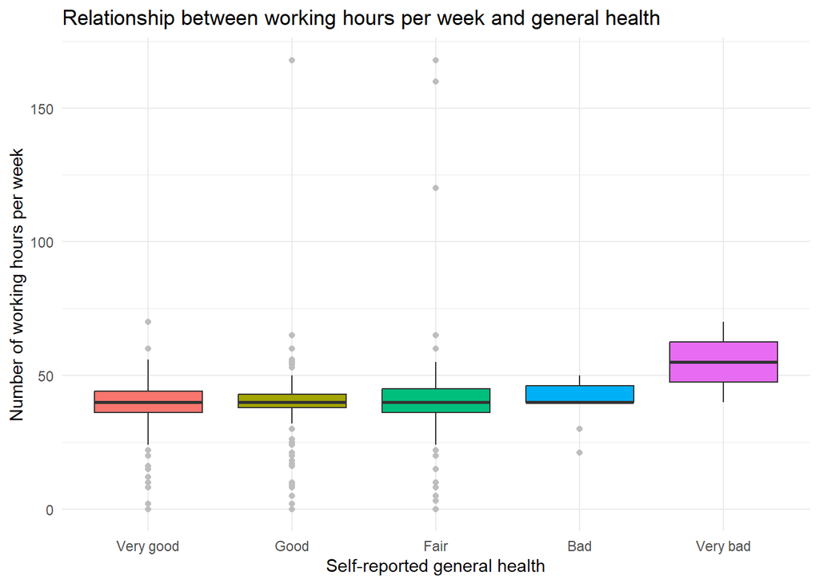

```r
ess_italy %>%
  ggplot(aes(health_levels, total_work_per_week, fill = health_levels)) +
  geom_boxplot(outlier.colour = 'gray') +
  theme_minimal() +
  theme(legend.position = 'none') +
  labs(
    title = 'Relationship between working hours per week and general health',
    x = 'Self-reported general health',
    y = 'Number of working hours per week',
    fill = 'Self-reported general health')
```

### Summary of findings

The results of the analysis are only partially definitive of the relationship between working life and health and Italy. We found out that the amount of working hours a week is connected to the subjective health evaluation among observations, where the poorest health is associated with the number of working hours beyond the standard (=40 hours). We also documented that while in general the subjective health of Italians in the sample is either good or very good, there are fluctuations among different types of organizations, where non-registered organizations (marked as “Other”) and governmental positions are associated with poorer health than in state-owned enterprises or under self-employment. Nevertheless, we couldn’t find any correspondence between different age and alcohol consumption patterns.

It is supposed that a more in-depth analysis should be conducted in order to address the research question with more confidence.